# Análisis de Componentes Principales

Autor

Meza A., Angel D.

Fecha de publicación

18 de abril de 2026

# Análisis de Componentes Principales

## Introducción al caso

El decatlón es una disciplina olímpica que combina diez pruebas atléticas en dos jornadas, abarcando capacidades físicas tan diversas como la velocidad explosiva, la potencia muscular, la coordinación técnica y la resistencia aeróbica. Los resultados en cada prueba no son independientes entre sí: un atleta con gran potencia en tren inferior tenderá a destacar simultáneamente en salto largo, salto de altura y lanzamientos, mientras que las pruebas de resistencia responden a una capacidad fisiológica distinta.

Evaluar el rendimiento de los atletas prueba por prueba de forma univariada resulta insuficiente, pues ignora la estructura de correlaciones que subyace al perfil físico de cada competidor. Por ello, se emplea el *Análisis de Componentes Principales (ACP)*, que permite reducir la dimensionalidad del espacio de diez pruebas, identificar las dimensiones latentes del rendimiento atlético y visualizar la posición relativa de los competidores en dicho espacio.

El análisis se aplica sobre los resultados de *33 atletas* que participaron en el decatlón de los *Juegos Olímpicos de 1988 (Seúl)*, con el objetivo de determinar cuántas dimensiones resumen adecuadamente el rendimiento global y qué agrupación de pruebas caracteriza a cada componente.

### Variables

| Variable | Prueba | Unidad |
| --- | --- | --- |
| `100` | Carrera de 100 metros | s |
| `long` | Salto largo | m |
| `poid` | Lanzamiento de bala | m |
| `haut` | Salto de altura | m |
| `400` | Carrera de 400 metros | s |
| `110` | Carrera de 110 metros con vallas | s |
| `disq` | Lanzamiento de disco | m |
| `perc` | Salto con pértiga | m |
| `jave` | Lanzamiento de jabalina | m |
| `1500` | Carrera de 1500 metros | s |

**Mostrar código**

```r
library(tidyverse)
library(ade4)
data(olympic)
datos <- olympic$tab
datos %>% str()
```

```
'data.frame':   33 obs. of  10 variables:
 $ 100 : num  11.2 10.9 11.2 10.6 11 ...
 $ long: num  7.43 7.45 7.44 7.38 7.43 7.72 7.05 6.95 7.12 7.28 ...
 $ poid: num  15.5 15 14.2 15 12.9 ...
 $ haut: num  2.27 1.97 1.97 2.03 1.97 2.12 2.06 2 2.03 1.97 ...
 $ 400 : num  48.9 47.7 48.3 49.1 47.4 ...
 $ 110 : num  15.1 14.5 14.8 14.7 14.4 ...
 $ disq: num  49.3 44.4 43.7 44.8 41.2 ...
 $ perc: num  4.7 5.1 5.2 4.9 5.2 4.9 5.7 4.8 4.9 5.2 ...
 $ jave: num  61.3 61.8 64.2 64 57.5 ...
 $ 1500: num  269 273 263 285 257 ...
```

**Visualización de las primeras 5 filas del dataset**

**Mostrar código**

```r
datos %>% head(5)
```

```
    100 long  poid haut   400   110  disq perc  jave   1500
1 11.25 7.43 15.48 2.27 48.90 15.13 49.28  4.7 61.32 268.95
2 10.87 7.45 14.97 1.97 47.71 14.46 44.36  5.1 61.76 273.02
3 11.18 7.44 14.20 1.97 48.29 14.81 43.66  5.2 64.16 263.20
4 10.62 7.38 15.02 2.03 49.06 14.72 44.80  4.9 64.04 285.11
5 11.02 7.43 12.92 1.97 47.44 14.40 41.20  5.2 57.46 256.64
```

**Examinar si hay datos perdidos en la dataframe**

**Mostrar código**

```r
library(naniar)
miss_case_summary(datos)
```

```
# A tibble: 33 × 3
    case n_miss pct_miss
   <int>  <int>    <dbl>
 1     1      0        0
 2     2      0        0
 3     3      0        0
 4     4      0        0
 5     5      0        0
 6     6      0        0
 7     7      0        0
 8     8      0        0
 9     9      0        0
10    10      0        0
# ℹ 23 more rows
```

*Interpretación*

El dataset está completo: ninguno de los 33 atletas presenta valores perdidos en ninguna de las 10 pruebas, por lo que no es necesario aplicar ningún procedimiento de imputación antes del ACP.

## Análisis Descriptivo

**Mostrar código**

```r
library(psych)
psych::describe(datos)
```

```
     vars  n   mean    sd median trimmed   mad    min    max range  skew
100     1 33  11.20  0.24  11.18   11.20  0.27  10.62  11.57  0.95 -0.16
long    2 33   7.13  0.30   7.09    7.16  0.28   6.22   7.72  1.50 -0.85
poid    3 33  13.98  1.33  14.12   14.02  1.33  10.27  16.60  6.33 -0.41
haut    4 33   1.98  0.09   1.97    1.98  0.09   1.79   2.27  0.48  0.54
400     5 33  49.28  1.07  49.15   49.24  1.23  47.44  51.28  3.84  0.23
110     6 33  15.05  0.51  15.00   15.03  0.50  14.18  16.20  2.02  0.32
disq    7 33  42.35  3.72  42.32   42.22  4.45  34.36  50.66 16.30  0.18
perc    8 33   4.74  0.33   4.70    4.74  0.30   4.00   5.70  1.70  0.31
jave    9 33  59.44  5.50  59.48   59.33  6.70  49.52  72.60 23.08  0.25
1500   10 33 276.04 13.66 272.06  275.43 13.54 256.64 303.17 46.53  0.47
     kurtosis   se
100     -0.84 0.04
long     1.11 0.05
poid     0.23 0.23
haut     1.29 0.02
400     -1.03 0.19
110     -0.53 0.09
disq    -0.54 0.65
perc     0.76 0.06
jave    -0.75 0.96
1500    -1.07 2.38
```

*Interpretación*

Las variables presentan escalas muy heterogéneas: las carreras se miden en segundos (valores entre ~11 s para los 100 m y ~276 s para los 1500 m), mientras que los lanzamientos y saltos se expresan en metros. Esta disparidad de escalas y varianzas hace imprescindible estandarizar antes del ACP.

En cuanto a la forma de las distribuciones, `long` muestra la asimetría negativa más marcada (skew = −0.85), indicando que la mayoría de atletas se concentra en distancias superiores a la media con pocos valores bajos. La variable `haut` presenta el mayor coeficiente de curtosis (1.29), con una distribución más apuntada que la normal. El resto de variables se mantiene en rangos moderados de asimetría y curtosis.

## Análisis de correlación

**Mostrar código**

```r
matriz_var_co <- cov(datos)
matriz_var_co
```

```
              100        long        poid         haut          400         110
100   0.059205114 -0.03995625 -0.06740426 -0.003336648  0.157696875  0.07871420
long -0.039956250  0.09262292  0.05752187  0.007812500 -0.167760417 -0.07372083
poid -0.067404261  0.05752187  1.77419886  0.015282102  0.134759375 -0.19961080
haut -0.003336648  0.00781250  0.01528210  0.008832955 -0.008796875 -0.01460909
400   0.157696875 -0.16776042  0.13475938 -0.008796875  1.144172917  0.29598333
110   0.078714205 -0.07372083 -0.19961080 -0.014609091  0.295983333  0.25681098
disq -0.042735227  0.04745208  3.99454602  0.051529545  0.565654167 -0.20825758
perc -0.031664773  0.03561458  0.21380398  0.006701705 -0.113989583 -0.08838826
jave -0.086542045  0.30386667  4.37533295  0.059884659  0.707533333 -0.17497027
1500  0.867431818 -1.64421667  4.89030994 -0.146436364  8.579279167  0.99175436
            disq         perc        jave        1500
100  -0.04273523 -0.031664773 -0.08654205   0.8674318
long  0.04745208  0.035614583  0.30386667  -1.6442167
poid  3.99454602  0.213803977  4.37533295   4.8903099
haut  0.05152955  0.006701705  0.05988466  -0.1464364
400   0.56565417 -0.113989583  0.70753333   8.5792792
110  -0.20825758 -0.088388258 -0.17497027   0.9917544
disq 13.83193712  0.427808712  9.05317992  20.4348530
perc  0.42780871  0.111837121  0.50404924  -0.1438447
jave  9.05317992  0.504049242 30.20599848   7.2338981
1500 20.43485303 -0.143844697  7.23389811 186.5163133
```

*Interpretación*

La matriz de covarianzas en escala original evidencia la extrema heterogeneidad de varianzas entre pruebas. `1500` presenta una varianza de ~186.5, mientras que `haut` apenas alcanza 0.008. Aplicar el ACP directamente sobre esta matriz haría que el primer componente capturara casi exclusivamente la variabilidad de `1500`, ignorando por completo la estructura latente de las demás pruebas.

### Matriz de dispersión

**Mostrar código**

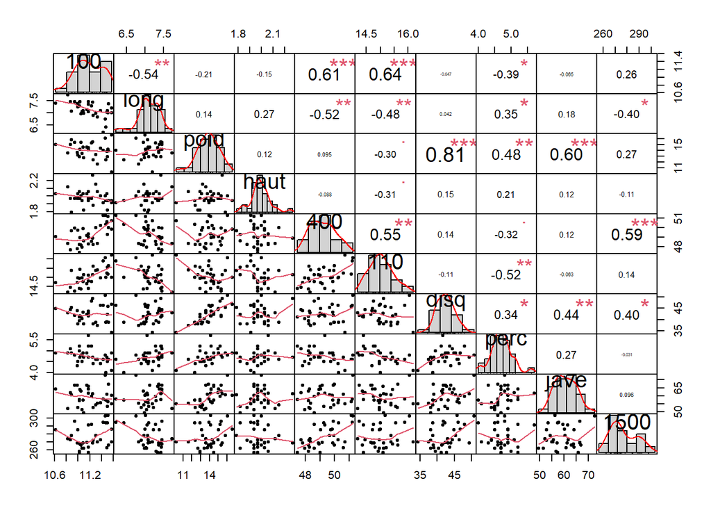

```r
library(PerformanceAnalytics)
chart.Correlation(datos, histogram = TRUE, pch = 20)
```

### Mapa de calor

**Mostrar código**

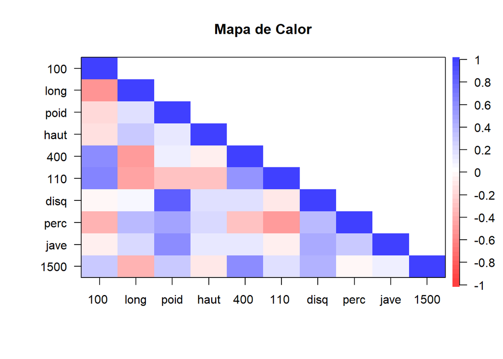

```r
library(psych)
cor.plot(cor(datos),
         main        = "Mapa de Calor",
         diag        = TRUE,
         show.legend = TRUE,
         numbers     = FALSE,
         upper       = FALSE)
```

## Análisis de Componentes Principales

### Estandarización de los datos

**Mostrar código**

```r
cov(datos)
```

```
              100        long        poid         haut          400         110
100   0.059205114 -0.03995625 -0.06740426 -0.003336648  0.157696875  0.07871420
long -0.039956250  0.09262292  0.05752187  0.007812500 -0.167760417 -0.07372083
poid -0.067404261  0.05752187  1.77419886  0.015282102  0.134759375 -0.19961080
haut -0.003336648  0.00781250  0.01528210  0.008832955 -0.008796875 -0.01460909
400   0.157696875 -0.16776042  0.13475938 -0.008796875  1.144172917  0.29598333
110   0.078714205 -0.07372083 -0.19961080 -0.014609091  0.295983333  0.25681098
disq -0.042735227  0.04745208  3.99454602  0.051529545  0.565654167 -0.20825758
perc -0.031664773  0.03561458  0.21380398  0.006701705 -0.113989583 -0.08838826
jave -0.086542045  0.30386667  4.37533295  0.059884659  0.707533333 -0.17497027
1500  0.867431818 -1.64421667  4.89030994 -0.146436364  8.579279167  0.99175436
            disq         perc        jave        1500
100  -0.04273523 -0.031664773 -0.08654205   0.8674318
long  0.04745208  0.035614583  0.30386667  -1.6442167
poid  3.99454602  0.213803977  4.37533295   4.8903099
haut  0.05152955  0.006701705  0.05988466  -0.1464364
400   0.56565417 -0.113989583  0.70753333   8.5792792
110  -0.20825758 -0.088388258 -0.17497027   0.9917544
disq 13.83193712  0.427808712  9.05317992  20.4348530
perc  0.42780871  0.111837121  0.50404924  -0.1438447
jave  9.05317992  0.504049242 30.20599848   7.2338981
1500 20.43485303 -0.143844697  7.23389811 186.5163133
```

**Mostrar código**

```r
cov(scale(datos))
```

```
             100        long        poid        haut         400         110
100   1.00000000 -0.53956763 -0.20797283 -0.14590755  0.60589539  0.63836152
long -0.53956763  1.00000000  0.14189682  0.27313528 -0.51532883 -0.47799594
poid -0.20797283  0.14189682  1.00000000  0.12207562  0.09458277 -0.29571686
haut -0.14590755  0.27313528  0.12207562  1.00000000 -0.08750434 -0.30673504
400   0.60589539 -0.51532883  0.09458277 -0.08750434  1.00000000  0.54602764
110   0.63836152 -0.47799594 -0.29571686 -0.30673504  0.54602764  1.00000000
disq -0.04722423  0.04192321  0.80635220  0.14742183  0.14218823 -0.11049751
perc -0.38913812  0.34992555  0.47997834  0.21322557 -0.31865911 -0.52154860
jave -0.06471440  0.18166750  0.59767262  0.11593538  0.12035232 -0.06282187
1500  0.26103415 -0.39558645  0.26882944 -0.11408736  0.58728182  0.14329760
            disq        perc        jave        1500
100  -0.04722423 -0.38913812 -0.06471440  0.26103415
long  0.04192321  0.34992555  0.18166750 -0.39558645
poid  0.80635220  0.47997834  0.59767262  0.26882944
haut  0.14742183  0.21322557  0.11593538 -0.11408736
400   0.14218823 -0.31865911  0.12035232  0.58728182
110  -0.11049751 -0.52154860 -0.06282187  0.14329760
disq  1.00000000  0.34396570  0.44290752  0.40231998
perc  0.34396570  1.00000000  0.27424163 -0.03149506
jave  0.44290752  0.27424163  1.00000000  0.09637566
1500  0.40231998 -0.03149506  0.09637566  1.00000000
```

*Interpretación*

Al comparar ambas matrices se aprecia que en escala original las varianzas oscilan entre 0.008 (`haut`) y 186.5 (`1500`), una diferencia de cuatro órdenes de magnitud. Tras la estandarización, todas las varianzas son iguales a 1 y la matriz de covarianza coincide exactamente con la matriz de correlaciones. Trabajar con datos estandarizados garantiza que cada prueba contribuya al ACP en función de su estructura de correlación, no de su escala de medición.

### Ajuste del ACP

**Mostrar código**

```r
library(ade4)
library(factoextra)

acp <- dudi.pca(datos,
                scannf = FALSE,
                scale  = TRUE,
                nf     = ncol(datos))
```

### Autovalores y varianza explicada

**Mostrar código**

```r
acp$eig
```

```
 [1] 3.4182381 2.6063931 0.9432964 0.8780212 0.5566267 0.4912275 0.4305952
 [8] 0.3067981 0.2669494 0.1018542
```

**Mostrar código**

```r
sum(acp$eig)
```

```
[1] 10
```

**Mostrar código**

```r
inertia.dudi(acp)
```

```
Inertia information:
Call: inertia.dudi(x = acp)

Decomposition of total inertia:
     inertia     cum  cum(%)
Ax1   3.4182   3.418   34.18
Ax2   2.6064   6.025   60.25
Ax3   0.9433   6.968   69.68
Ax4   0.8780   7.846   78.46
Ax5   0.5566   8.403   84.03
Ax6   0.4912   8.894   88.94
Ax7   0.4306   9.324   93.24
Ax8   0.3068   9.631   96.31
Ax9   0.2669   9.898   98.98
Ax10  0.1019  10.000  100.00
```

*Interpretación*

La traza de la matriz es igual a 10, confirmando que el ACP se realizó sobre la matriz de correlaciones. Aplicando el **criterio de Kaiser** (retener componentes con autovalor > 1), se retienen **2 componentes principales**:

| Componente | Autovalor | Varianza explicada | Acumulado |
| --- | --- | --- | --- |
| CP1 | 3.418 | 34.18 % | 34.18 % |
| CP2 | 2.606 | 26.06 % | 60.25 % |
| CP3 | 0.943 | 9.43 % | 69.68 % |

Entre CP1 y CP2 se acumula el **60.25 %** de la variabilidad total. A partir de CP3 los autovalores caen por debajo de 1, lo que significa que cada componente adicional aporta menos información que una sola variable original estandarizada.

### Scree Plot — criterio de retención

**Mostrar código**

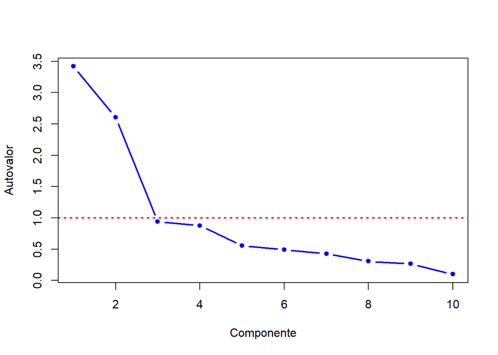

Figura 1: Scree plot con línea de referencia en λ = 1 (criterio de Kaiser)

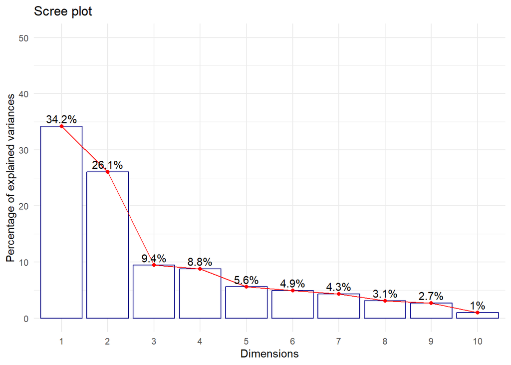

```r
# Primera forma
plot(acp$eig, type = "b", pch = 20, col = "blue", lwd = 2,
     xlab = "Componente", ylab = "Autovalor")
abline(h = 1, lty = 3, col = "red", lwd = 2)

# Segunda forma
fviz_eig(acp, addlabels = TRUE, hjust = 0.5,
         barfill   = "white",
         barcolor  = "darkblue",
         linecolor = "red") +
  ylim(0, 50) +
  theme_minimal()
```

*Interpretación*

Ambas formas del scree plot coinciden en el mismo mensaje. En la primera (gráfico de puntos), la curva cae abruptamente de CP1 (λ = 3.42) a CP2 (λ = 2.61) y luego de CP2 a CP3 (λ = 0.94), donde cruza la línea roja de referencia en λ = 1 y se aplana visiblemente a partir de ahí. El codo se produce entre CP2 y CP3, marcando el punto a partir del cual la ganancia en varianza explicada es marginal. En la segunda forma (gráfico de barras), CP1 explica el 34.2 % y CP2 el 26.1 %, sumando juntos el 60.3 %; desde CP3 en adelante ninguna barra supera el 10 % y el descenso se vuelve gradual y uniforme. Ambos criterios —Kaiser y codo— convergen en retener **2 componentes principales**.

### Vectores propios y correlaciones variables–componentes

**Mostrar código**

```r
# Coeficientes (vectores propios)
acp$c1
```

```
            CS1        CS2         CS3         CS4          CS5         CS6
100   0.4158823  0.1488081 -0.26747198  0.08833244 -0.442314456  0.03071237
long -0.3940515 -0.1520815 -0.16894945  0.24424963  0.368913901 -0.09378242
poid -0.2691057  0.4835374  0.09853273  0.10776276 -0.009754680  0.23002054
haut -0.2122818  0.0278985 -0.85498656 -0.38794393 -0.001876311  0.07454380
400   0.3558474  0.3521598 -0.18949642 -0.08057457  0.146965351 -0.32692886
110   0.4334816  0.0695682 -0.12616012  0.38229029 -0.088802794  0.21049130
disq -0.1757923  0.5033347  0.04609969 -0.02558404  0.019358607  0.61491241
perc -0.3840821  0.1495820  0.13687235 -0.14396548 -0.716743474 -0.34776037
jave -0.1799436  0.3719570 -0.19232803  0.60046566  0.095582043 -0.43744387
1500  0.1701426  0.4209653  0.22255233 -0.48564231  0.339772188 -0.30032419
            CS7          CS8         CS9        CS10
100  -0.2543985  0.663712826 -0.10839531 -0.10948045
long -0.7505343  0.141264141  0.04613910 -0.05580431
poid  0.1106637  0.072505560  0.42247611 -0.65073655
haut  0.1351242 -0.155435871 -0.10206505 -0.11941181
400  -0.1413388 -0.146839303  0.65076229  0.33681395
110  -0.2725296 -0.639003579 -0.20723854 -0.25971800
disq -0.1439726  0.009400445 -0.16724055  0.53450315
perc -0.2732665 -0.276873049 -0.01766443  0.06589572
jave  0.3419099  0.058519366 -0.30619617  0.13093187
1500 -0.1868704  0.007310045 -0.45688227 -0.24311846
```

**Mostrar código**

```r
# Correlaciones variables–componentes
acp$co
```

```
          Comp1       Comp2       Comp3       Comp4        Comp5       Comp6
100   0.7689031  0.24024073 -0.25977801  0.08276995 -0.329999387  0.02152557
long -0.7285412 -0.24552536 -0.16408953  0.22886871  0.275237129 -0.06572987
poid -0.4975355  0.78063857  0.09569838  0.10097671 -0.007277715  0.16121594
haut -0.3924767  0.04504025 -0.83039242 -0.36351428 -0.001399867  0.05224598
400   0.6579077  0.56853834 -0.18404546 -0.07550062  0.109647051 -0.22913668
110   0.8014415  0.11231318 -0.12253105  0.35821666 -0.066253470  0.14752835
disq -0.3250132  0.81260004  0.04477360 -0.02397295  0.014442957  0.43097750
perc -0.7101094  0.24149011  0.13293514 -0.13489967 -0.534743786 -0.24373698
jave -0.3326883  0.60049956 -0.18679561  0.56265307  0.071311293 -0.30659402
1500  0.3145678  0.67962013  0.21615050 -0.45506038  0.253495250 -0.21049009
           Comp7        Comp8        Comp9      Comp10
100  -0.16693567  0.367626287 -0.056004765 -0.03494024
long -0.49249877  0.078245304  0.023838755 -0.01780972
poid  0.07261722  0.040160366  0.218281354 -0.20767995
haut  0.08866817 -0.086094934 -0.052734102 -0.03810980
400  -0.09274620 -0.081333350  0.336230314  0.10749282
110  -0.17883327 -0.353939993 -0.107074242 -0.08288795
disq -0.09447447  0.005206846 -0.086408421  0.17058453
perc -0.17931681 -0.153358210 -0.009126707  0.02103035
jave  0.22436043  0.032413502 -0.158202825  0.04178638
1500 -0.12262390  0.004048987 -0.236058037 -0.07759028
```

*Interpretación*

**Componente 1 (34.18 %)** — *Velocidad y explosividad de tren inferior*

CP1 está definido principalmente por `110` (r = 0.801), `100` (r = 0.769), `400` (r = 0.658), `long` (r = −0.729) y `perc` (r = −0.710). Las tres carreras de velocidad cargan positivamente: a mayor tiempo, peor rendimiento y mayor valor en CP1. Los saltos largo y con pértiga cargan negativamente: mayor distancia implica mejor rendimiento y score más negativo en CP1. Esta componente opone a los atletas lentos (valores positivos) frente a los veloces y explosivos (valores negativos), y representa la capacidad neuromuscular de generación rápida de fuerza en tren inferior.

### Círculo de correlaciones

**Mostrar código**

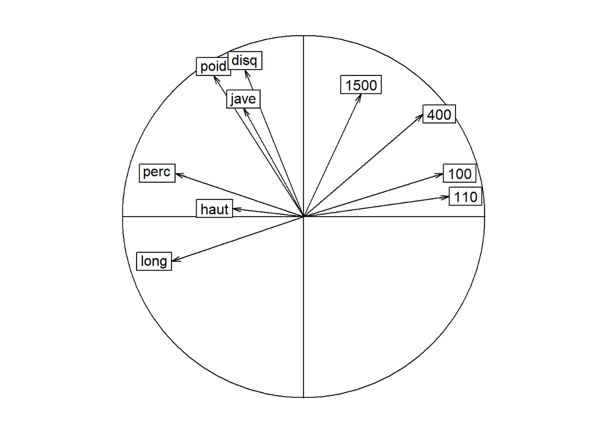

Figura 3: Círculo de correlaciones sobre CP1 y CP2

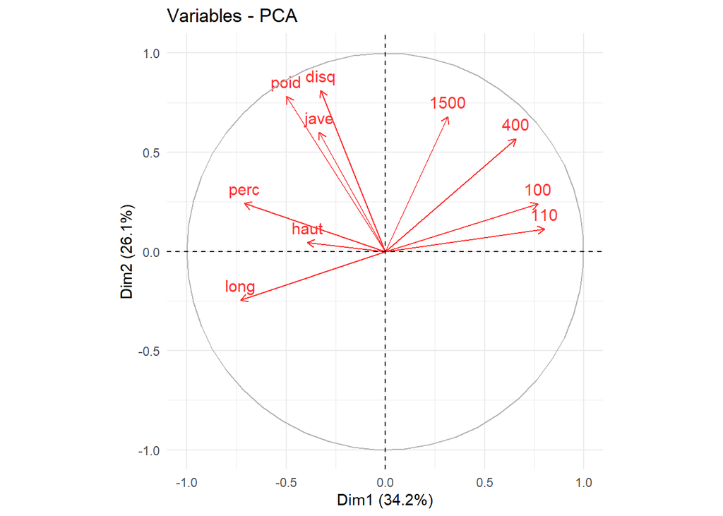

Figura 4: Círculo de correlaciones sobre CP1 y CP2

```r
# Primera forma
s.corcircle(acp$co, grid = FALSE, xax = 1, yax = 2)

# Segunda forma
fviz_pca_var(acp, col.var = "#FF3030") + theme_minimal()
```

*Interpretación*

Ambas versiones del círculo de correlaciones muestran la misma estructura. Las flechas de `100`, `110` y `400` apuntan hacia la derecha sobre el eje horizontal (CP1 positivo) y son largas, indicando alta correlación con CP1 y buena representación en el plano. Las flechas de `poid` y `disq` son casi paralelas entre sí y apuntan hacia arriba-izquierda, con fuerte proyección sobre CP2; `jave` sigue la misma dirección pero con un vector ligeramente más corto. La flecha de `long` apunta hacia abajo-izquierda, con carga negativa tanto en CP1 como en CP2, separándose del grupo de lanzamientos. La flecha de `perc` apunta hacia la izquierda con una leve componente positiva en CP2, asociándose a CP1 negativo. La variable `1500` apunta hacia arriba-derecha, con carga positiva en ambos componentes: comparte el semiplano derecho con las carreras de velocidad en CP1, pero se aleja hacia arriba por su carga en CP2. La flecha de `haut` es notablemente más corta que las demás y apunta casi horizontalmente hacia la izquierda, indicando que esta variable tiene baja representación en el plano CP1–CP2 y que su variabilidad se distribuye principalmente en componentes no mostrados.

### Scores de los individuos

**Mostrar código**

```r
round(acp$li[1:6, ], 3)
```

```
   Axis1  Axis2  Axis3  Axis4  Axis5  Axis6  Axis7  Axis8  Axis9 Axis10
1 -1.760  1.250 -2.834 -0.295  0.159  1.771 -0.270 -0.095 -0.257 -0.182
2 -2.830 -0.102  0.851  0.136  0.062  0.097 -0.039  0.019 -0.333 -0.105
3 -1.908 -0.139  0.045  0.985 -0.925 -0.226 -0.444  0.236 -0.285  0.294
4 -2.349  0.807  0.352 -0.264  1.361 -0.335  0.295 -1.125 -0.103  0.077
5 -2.296 -2.050  0.489  0.074 -0.976 -0.102 -0.255  0.279 -0.267  0.543
6 -2.717 -1.455 -0.531 -1.668  0.899  0.314 -0.905  0.040  0.196  0.225
```

**Mostrar código**

```r
# Verificar independencia entre componentes
round(cor(acp$li), 4)
```

```
       Axis1 Axis2 Axis3 Axis4 Axis5 Axis6 Axis7 Axis8 Axis9 Axis10
Axis1      1     0     0     0     0     0     0     0     0      0
Axis2      0     1     0     0     0     0     0     0     0      0
Axis3      0     0     1     0     0     0     0     0     0      0
Axis4      0     0     0     1     0     0     0     0     0      0
Axis5      0     0     0     0     1     0     0     0     0      0
Axis6      0     0     0     0     0     1     0     0     0      0
Axis7      0     0     0     0     0     0     1     0     0      0
Axis8      0     0     0     0     0     0     0     1     0      0
Axis9      0     0     0     0     0     0     0     0     1      0
Axis10     0     0     0     0     0     0     0     0     0      1
```

*Interpretación*

La matriz de correlaciones entre componentes muestra valores exactamente iguales a cero en todos los pares, confirmando la **ortogonalidad** de las componentes: cada una captura información completamente independiente de las demás.

### Gráfico de individuos

**Mostrar código**

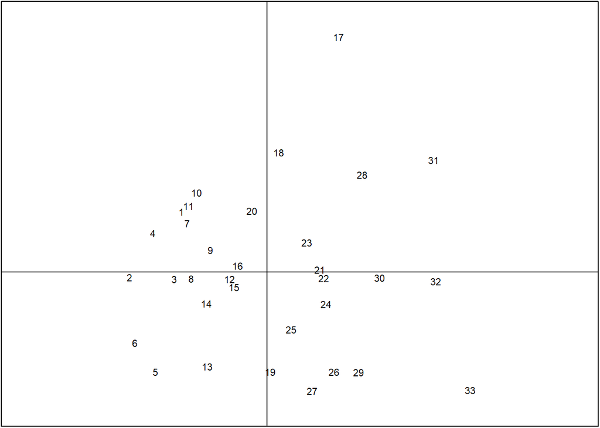

Figura 5: Posición de los atletas en el primer plano principal

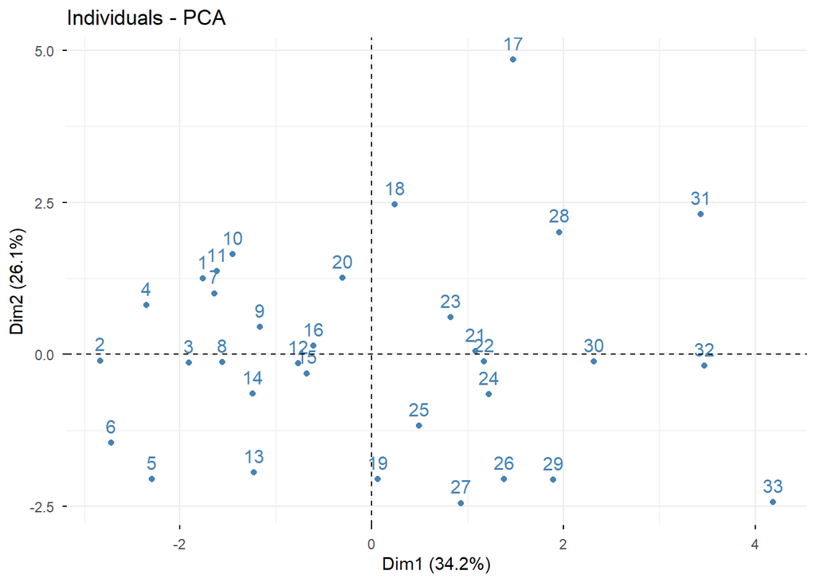

Figura 6: Posición de los atletas en el primer plano principal

```r
# Primera forma
s.label(acp$li, xax = 1, yax = 2,
        clabel = 0.7, grid = FALSE, boxes = FALSE)

# Segunda forma
fviz_pca_ind(acp, col.ind = "steelblue")
```

*Interpretación*

El gráfico ubica a los 33 atletas en el plano CP1–CP2. Se observa que la mayoría de los competidores se concentra en el cuadrante superior-izquierdo e inferior-izquierdo (atletas 1–16 aproximadamente), con scores negativos en CP1, lo que indica que el grupo analizado es en general rápido y explosivo. Los atletas del lado derecho del eje (21, 22, 30, 31, 32, 33) presentan tiempos más altos en las carreras, es decir, menor velocidad.

El atleta 17 es el más extremo en CP2 positivo (~5.0), destacando notablemente sobre el resto en la dimensión de lanzamientos y resistencia. En el extremo opuesto de CP2, el atleta 33 (~−2.5) es el que menos se asocia a esa dimensión. Los atletas 2, 5 y 6, ubicados en el cuadrante inferior-izquierdo, combinan velocidad elevada (CP1 negativo) con bajo score en CP2, mostrando un perfil especializado en velocidad y explosividad pero no en lanzamientos.

### Biplot

**Mostrar código**

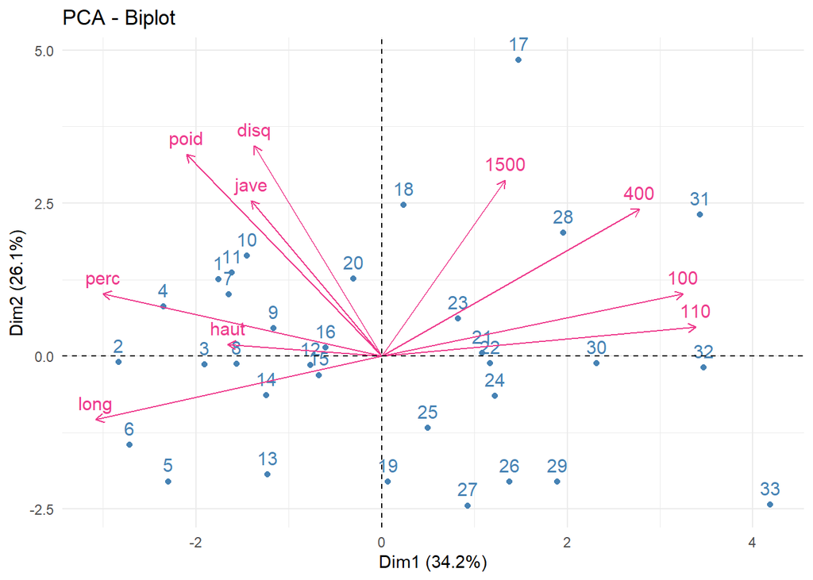

Figura 7: Biplot: variables (flechas) e individuos (puntos) sobre CP1–CP2

```r
fviz_pca_biplot(acp,
                repel   = FALSE,
                col.var = "#EE3A8C",
                col.ind = "steelblue") +
  theme_minimal()
```

*Interpretación*

El biplot integra la información del círculo de correlaciones y el gráfico de individuos en una sola representación. Los atletas 2, 5 y 6, ubicados en el extremo izquierdo, se proyectan en la dirección opuesta a las carreras de velocidad: son los más rápidos del grupo. El atleta 17, en el extremo superior, se proyecta en la dirección de `poid`, `disq` y `jave`, siendo el más potente en lanzamientos. Los atletas 31, 32 y 33, en el semiplano derecho, se alinean con las flechas de `100`, `110` y `400`, indicando que son los más lentos en velocidad. El atleta 4, en el cuadrante superior-izquierdo, se proyecta tanto en la dirección de `perc` como parcialmente hacia `poid` y `disq`, sugiriendo un perfil con buena explosividad y potencia de lanzamiento. La nube de puntos no presenta grupos claramente separados, lo que confirma que el rendimiento en decatlón varía de forma continua y que los perfiles altamente especializados —ya sea en velocidad pura o en lanzamientos puros— son los que más se alejan del centro.

### Exportar resultados

**Mostrar código**

```r
salida_acp <- cbind(datos, acp$li[, 1:3])
head(salida_acp)
```

```
    100 long  poid haut   400   110  disq perc  jave   1500     Axis1
1 11.25 7.43 15.48 2.27 48.90 15.13 49.28  4.7 61.32 268.95 -1.759830
2 10.87 7.45 14.97 1.97 47.71 14.46 44.36  5.1 61.76 273.02 -2.830456
3 11.18 7.44 14.20 1.97 48.29 14.81 43.66  5.2 64.16 263.20 -1.908359
4 10.62 7.38 15.02 2.03 49.06 14.72 44.80  4.9 64.04 285.11 -2.349010
5 11.02 7.43 12.92 1.97 47.44 14.40 41.20  5.2 57.46 256.64 -2.295762
6 10.83 7.72 13.58 2.12 48.34 14.18 43.06  4.9 52.18 274.07 -2.716695
       Axis2       Axis3
1  1.2504617 -2.83416614
2 -0.1022408  0.85141131
3 -0.1390149  0.04528333
4  0.8068930  0.35227057
5 -2.0504171  0.48851745
6 -1.4547536 -0.53052034
```

**Mostrar código**

```r
write.csv(salida_acp, "resultados_acp.csv", row.names = TRUE)
```

## Conclusiones

El ACP aplicado a los resultados del decatlón olímpico de Seúl 1988 permite extraer las siguientes conclusiones:

1. **La estandarización es indispensable.** Las pruebas del decatlón presentan varianzas que van desde 0.008 (`haut`) hasta 186.5 (`1500`), una diferencia de cuatro órdenes de magnitud. Trabajar con la matriz de correlaciones garantiza que cada prueba contribuya al análisis en función de su estructura de asociación con las demás, no de su unidad de medición.
2. **Dos componentes resumen el rendimiento global.** CP1 y CP2 acumulan el 60.25 % de la variabilidad total, cumpliendo el criterio de Kaiser y el codo del scree plot. Esta reducción de 10 variables a 2 dimensiones interpretables es suficiente para caracterizar el perfil atlético de los competidores.
3. **CP1 separa a los atletas por velocidad y explosividad.** Las carreras de 100 m, 110 m con vallas y 400 m, junto con el salto largo y el salto con pértiga, definen esta dimensión. Los atletas con scores negativos en CP1 son los más rápidos y explosivos del grupo.
4. **CP2 distingue a los atletas por potencia de lanzamiento.** El disco, la bala y la jabalina son las variables que más pesan en esta componente, representando la capacidad de fuerza de tren superior. El atleta 17 sobresale de forma marcada en esta dimensión, con un score de ~5.0 que lo separa claramente del resto del grupo.
5. **Los perfiles de velocidad y potencia son independientes entre sí.** La correlación entre CP1 y CP2 es exactamente cero, confirmando que ser veloz no implica ser potente en lanzamientos, y viceversa. Ambas capacidades son dimensiones ortogonales del rendimiento en decatlón.
6. **El rendimiento en decatlón es continuo y no se agrupa en perfiles discretos.** La nube de individuos en el plano principal no muestra conglomerados separados, sino una distribución gradual. Los extremos —atletas 2, 5, 6 en velocidad; atleta 17 en lanzamientos; atletas 31, 32, 33 en lentitud— son los que más se alejan del perfil promedio.